# CMap Drug Safety Challenge

Joaquim Aguirre-Plans

March 28, 2019

## Explore files

First I load the files and explore the objects loaded

```r
load(drugs_file)
load(drug_info_file)
load(dilirank_file)
load(expression_file) # Requires cmapR
```

### selDrugs

selDrugs contains the drugs that we work with:

```r
summary(selDrugs)
```

```
##    Length     Class      Mode
##      1314 character character
```

### selDrugsInfo13

selDrugsInfo13 contains the information about the InChiKey and SMILES of the drugs:

```r
summary(selDrugsInfo13)
```

```
##   pert_iname         inchi_key         canonical_smiles
##  Length:1696        Length:1696        Length:1696
##  Class :character   Class :character   Class :character
##  Mode  :character   Mode  :character   Mode  :character
##  pubchem_cid
##  Length:1696
##  Class :character
##  Mode  :character
```

### drank.sel

drank.sel contains the information about the DILIRank and additional information about the drugs:

```r
summary(drank.sel)
```

```
##     LTKBID          PubChem_CID        Compound.Name
##  Length:233         Length:233         Length:233
##  Class :character   Class :character   Class :character
##  Mode  :character   Mode  :character   Mode  :character
##
##
##
##  ApprovalYear       DILIConcern        Severity.Class  Label.Section
##  Length:233         Length:233         Min.   :0.000   Length:233
##  Class :character   Class :character   1st Qu.:2.000   Class :character
##  Mode  :character   Mode  :character   Median :3.000   Mode  :character
##                                        Mean   :3.348
##                                        3rd Qu.:5.000
##                                        Max.   :8.000
##  AdjudicatedDILI    vDILIConcern       Greene_Annotation
##  Length:233         Length:233         Length:233
##  Class :character   Class :character   Class :character
##  Mode  :character   Mode  :character   Mode  :character
##
##
##
##  Sakatis_Annotation Xu_Annotation      Zhu_Annotation
##  Length:233         Length:233         Length:233
##  Class :character   Class :character   Class :character
##  Mode  :character   Mode  :character   Mode  :character
##
##
##
##     SMILES          URL..accessed.on.1.21.2016.
##  Length:233         Length:233
##  Class :character   Class :character
##  Mode  :character   Mode  :character
##
##
##
##  VER_DISP..1.LTKB.BD..2.others.  pert_iname
##  Min.   :1.000                  Length:233
##  1st Qu.:1.000                  Class :character
##  Median :2.000                  Mode  :character
##  Mean   :1.665
##  3rd Qu.:2.000
##  Max.   :2.000
```

In the drank.sel object we have extensive information about each drug:

- **pert_iname**: “perturbation name”, the name of the drug

```r
drank.sel$pert_iname[0:10]
```

```
##  [1] "alaproclate" "acitretin"   "amiodarone"  "danazol"     "dantrolene"
##  [6] "felbamate"   "lapatinib"   "leflunomide" "mexiletine"  "pazopanib"
```

- **Other identifiers of the drug**:

```r
drank.sel$Compound.Name[0:10]
```

```
##  [1] "alaproclate" "acitretin"   "amiodarone"  "danazol"     "dantrolene"
##  [6] "felbamate"   "lapatinib"   "leflunomide" "mexiletine"  "pazopanib"
```

```r
drank.sel$LTKBID[0:10]
```

```
##  [1] "LT02213" "LT01042" "LT00046" "LT00539" "LT00080" "LT00097" "LT02204"
##  [8] "LT00113" "LT01553" "LT00672"
```

```r
drank.sel$PubChem_CID[0:10]
```

```
##  [1] "2081"     "6437841"  "2157"     "28417"    "2952"     "3331"
##  [7] "208908"   "3899"     "4178"     "10113978"
```

- **The SMILES**:

```r
drank.sel$SMILES[0:10]
```

```
##  [1] "CC(C(=O)OC(C)(C)CC1=CC=C(C=C1)Cl)N"
##  [2] "CC1=CC(=C(C(=C1/C=C/C(=C/C=C/C(=C\\C(=O)O)/C)/C)C)C)OC"
##  [3] "CCCCC1=C(C2=CC=CC=C2O1)C(=O)C3=CC(=C(C(=C3)I)OCCN(CC)CC)I"
##  [4] "C[C@]12CC[C@H]3[C@H]([C@@H]1CC[C@]2(C#C)O)CCC4=CC5=C(C[C@]34C)C=NO5"
##  [5] "C1C(=O)NC(=O)N1N=CC2=CC=C(O2)C3=CC=C(C=C3)[N+](=O)[O-]"
##  [6] "C1=CC=C(C=C1)C(COC(=O)N)COC(=O)N"
##  [7] "CS(=O)(=O)CCNCC1=CC=C(O1)C2=CC3=C(C=C2)N=CN=C3NC4=CC(=C(C=C4)OCC5=CC(=CC=C5)F)Cl"
##  [8] "CC1=C(C=NO1)C(=O)NC2=CC=C(C=C2)C(F)(F)F"
##  [9] "CC1=C(C(=CC=C1)C)OCC(C)N"
## [10] "CC1=C(C=C(C=C1)NC2=NC=CC(=N2)N(C)C3=CC4=NN(C(=C4C=C3)C)C)S(=O)(=O)N"
```

- **DILIConcern**: The classes of concert in DILIRank

```r
drank.sel$DILIConcern[drank.sel$DILIConcern == "No-DILI-concern"] <- "No-DILI-Concern" # Correct the 4 entries with lowercase concern
# Assign simple names to DILIConcern labels
drank.sel$DILIConcern[drank.sel$DILIConcern == "Most-DILI-Concern"] <- "Most"
drank.sel$DILIConcern[drank.sel$DILIConcern == "Less-DILI-Concern"] <- "Less"
drank.sel$DILIConcern[drank.sel$DILIConcern == "No-DILI-Concern"] <- "No"
# Check number of drugs in each class
table(drank.sel$DILIConcern)
```

```
##
## Less Most   No
##  140   39   54
```

- **Additional information related with the DILIRank concern**:

```r
table(drank.sel$Severity.Class) # 7-8 = Most, 2-6 = Less, 0 = No
```

```
##
##  0  2  3  4  5  6  7  8
## 54 12 85 16 26  1 11 28
```

```r
table(drank.sel$vDILIConcern)
```

```
##
## Ambiguous DILI-concern     vLess-DILI-Concern     vMost-DILI-Concern
##                     55                     90                     37
##       vNo-DILI-Concern
##                     51
```

```r
table(drank.sel$AdjudicatedDILI)
```

```
##
##   . Yes
## 107 126
```

```r
table(drank.sel$Label.Section)
```

```
##
##        Adverse reactions              Box warning                 No match
##                       97                       10                       54
## Warnings and precautions                Withdrawn
##                       71                        1
```

- **Other measures of DILI concern**:

```r
table(drank.sel$Greene_Annotation)
```

```
##
##   .  HH  NE  WE
## 123  56  28  26
```

```r
table(drank.sel$Sakatis_Annotation)
```

```
##
##               .     Hepatotoxic non-hepatotixic
##             171              25              37
```

```r
table(drank.sel$Xu_Annotation)
```

```
##
##        . Negative Positive
##      113       62       58
```

```r
table(drank.sel$Zhu_Annotation)
```

```
##
##        . Negative  Postive
##      169       14       50
```

### gct

gct is a cmapR object. In the gct object, the rows are genes (in Entrez Gene ID) and the columns are samples of cell lines after drug administration in different conditions:

```r
summary(gct)
```

```
## Length  Class   Mode
##      1    GCT     S4
```

```r
summary(gct@rid)
```

```
##    Length     Class      Mode
##     12328 character character
```

```r
summary(gct@cid)
```

```
##    Length     Class      Mode
##     48468 character character
```

In the gct object there is the “cdesc” field which provides us with different types of information of the samples:

```r
summary(gct@cdesc)
```

```
##       id               sig_id            pert_id
##  Length:48468       Length:48468       Length:48468
##  Class :character   Class :character   Class :character
##  Mode  :character   Mode  :character   Mode  :character
##
##
##
##   pert_iname         pert_type           cell_id
##  Length:48468       Length:48468       Length:48468
##  Class :character   Class :character   Class :character
##  Mode  :character   Mode  :character   Mode  :character
##
##
##
##   pert_dose         pert_dose_unit      pert_idose          pert_time
##  Length:48468       Length:48468       Length:48468       Min.   : 6.00
##  Class :character   Class :character   Class :character   1st Qu.: 6.00
##  Mode  :character   Mode  :character   Mode  :character   Median :24.00
##                                                           Mean   :15.21
##                                                           3rd Qu.:24.00
##                                                           Max.   :48.00
##  pert_time_unit      pert_itime         distil_id
##  Length:48468       Length:48468       Length:48468
##  Class :character   Class :character   Class :character
##  Mode  :character   Mode  :character   Mode  :character
##
##
##
```

Here I provide a small description of the most relevant fields:

- **pert_id**: “perturbation ID”, the identifier of the drug

```r
gct@cdesc$pert_id[0:10]
```

```
##  [1] "BRD-K20482099" "BRD-A14966924" "BRD-K79131256" "BRD-A90131694"
##  [5] "BRD-A09056319" "BRD-K30020243" "BRD-A27554692" "BRD-A36010170"
##  [9] "BRD-K43068349" "BRD-K94512704"
```

- **pert_iname**: “perturbation name”, the name of the drug

```r
gct@cdesc$pert_iname[0:10]
```

```
##  [1] "rutin"         "alaproclate"   "albendazole"   "alclometasone"
##  [5] "alfuzosin"     "aliskiren"     "altrenogest"   "amcinonide"
##  [9] "AMG-9810"      "spiramide"
```

- **pert_type**: “perturbation type”

```r
unique(gct@cdesc$pert_type)
```

```
## [1] "trt_cp"
```

- **cell_id**: “cell identifier”, type of cell line

```r
unique(gct@cdesc$cell_id)
```

```
##  [1] "A375"     "A549"     "HA1E"     "HCC515"   "HEPG2"    "HT29"
##  [7] "MCF7"     "PC3"      "VCAP"     "SW480"    "ASC"      "NEU"
## [13] "NPC"      "PHH"      "SKB"      "BT20"     "HS578T"   "MCF10A"
## [19] "MDAMB231" "SKBR3"    "FIBRNPC"  "NKDBA"    "HEK293T"
```

- **pert_dose**: “perturbation dose”, dose of the drug administration

```r
unique(gct@cdesc$pert_dose)[0:20]
```

```
##  [1] "10.0"   "2.0"    "0.4"    "0.08"   "20.0"   "80.0"   "28.39"
##  [8] "1.0"    "0.09"   "88.8"   "0.63"   "22.2"   "4.21"   "40.0"
## [15] "160.0"  "122.55" "69.83"  "44.4"   "11.1"   "9.68"
```

- **pert_dose_unit**: “perturbation dose unit”, unit of the dose

```r
unique(gct@cdesc$pert_dose_unit)
```

```
## [1] "µM"
```

- **pert_idose**: “perturbation idose”, dose + unit

```r
unique(gct@cdesc$pert_idose)
```

```
##  [1] "10 µM"   "1 µM"    "500 nM"  "100 nM"  "20 µM"   "80 µM"   "30 µM"
##  [8] "90 µM"   "5 µM"    "40 µM"   "100 µM"  "70 µM"   "60 µM"   "3 µM"
## [15] "50 µM"   "10 nM"   "1 nM"    "1.11 µM" "0.37 µM" "0.12 µM" "0.04 µM"
## [22] "3.33 µM"
```

- **pert_time**: “perturbation time”, duration of the dose administration

```r
unique(gct@cdesc$pert_time)
```

```
## [1]  6 24 48
```

- **pert_time_unit**: “perturbation time unit”, unit of time

```r
unique(gct@cdesc$pert_time_unit)
```

```
## [1] "h"
```

- **pert_itime**: “perturbation itime”, time + unit

```r
unique(gct@cdesc$pert_itime)
```

```
## [1] "6 h"  "24 h" "48 h"
```

- **distil_id**: ID of an individual replicate profile

```r
gct@cdesc$distil_id[0:10]
```

```
##  [1] "CPC004_A375_6H_X1_B3_DUO52HI53LO:K13|CPC004_A375_6H_X2_B3_DUO52HI53LO:K13|CPC004_A375_6H_X3_B3_DUO52HI53LO:K13"
##  [2] "CPC004_A375_6H_X1_B3_DUO52HI53LO:J04|CPC004_A375_6H_X2_B3_DUO52HI53LO:J04|CPC004_A375_6H_X3_B3_DUO52HI53LO:J04"
##  [3] "CPC004_A375_6H_X1_B3_DUO52HI53LO:H04|CPC004_A375_6H_X2_B3_DUO52HI53LO:H04|CPC004_A375_6H_X3_B3_DUO52HI53LO:H04"
##  [4] "CPC004_A375_6H_X1_B3_DUO52HI53LO:L22|CPC004_A375_6H_X3_B3_DUO52HI53LO:L22"
##  [5] "CPC004_A375_6H_X1_B3_DUO52HI53LO:H15|CPC004_A375_6H_X2_B3_DUO52HI53LO:H15|CPC004_A375_6H_X3_B3_DUO52HI53LO:H15"
##  [6] "CPC004_A375_6H_X1_B3_DUO52HI53LO:N11|CPC004_A375_6H_X2_B3_DUO52HI53LO:N11|CPC004_A375_6H_X3_B3_DUO52HI53LO:N11"
##  [7] "CPC004_A375_6H_X1_B3_DUO52HI53LO:N03|CPC004_A375_6H_X2_B3_DUO52HI53LO:N03|CPC004_A375_6H_X3_B3_DUO52HI53LO:N03"
##  [8] "CPC004_A375_6H_X1_B3_DUO52HI53LO:H02|CPC004_A375_6H_X2_B3_DUO52HI53LO:H02|CPC004_A375_6H_X3_B3_DUO52HI53LO:H02"
##  [9] "CPC004_A375_6H_X1_B3_DUO52HI53LO:M12|CPC004_A375_6H_X2_B3_DUO52HI53LO:M12|CPC004_A375_6H_X3_B3_DUO52HI53LO:M12"
## [10] "CPC004_A375_6H_X1_B3_DUO52HI53LO:I24|CPC004_A375_6H_X2_B3_DUO52HI53LO:I24|CPC004_A375_6H_X3_B3_DUO52HI53LO:I24"
```

## Subset the gene expression data

There are three relevant parameters if we want to subset the gene expression data of a given drug:

- cell_id: The type of cell line
- pert_idose: The quantity of drug dose
- pert_itime: The duration of drug dose

Let’s analyse the example of the drug voriconazole that is actually in the DILI category “Most-DILI-Concern”:

```r
drank.sel$DILIConcern[drank.sel$pert_iname=="voriconazole"]
```

```
## [1] "Most"
```

We subset the drug information using the following command:

```r
idx <- which(gct@cdesc$pert_iname=="voriconazole")
x <- subset.gct(gct, cid=idx)
```

And now we can analyse the distribution of expression values (z-score) in each sample for the gene 1 for each time and cell line:

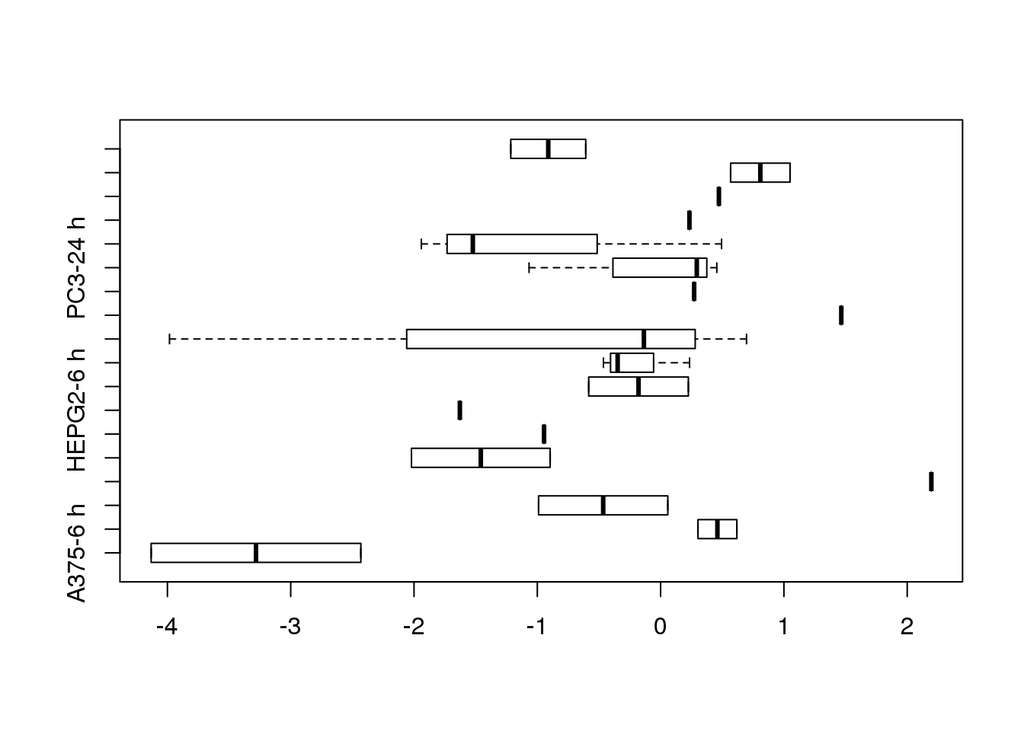

```r
labs = apply(x@cdesc[,c("cell_id","pert_itime")], 1, function(y) { paste0(y, collapse="-")})
s = split(x@mat[1,], labs)
boxplot(s,horizontal = T)
```

We observe that there is a great variation in expression for one gene, so to unify all the samples in one value will be a challenge!

## Analysis of gene expression similarity between pairs drugs in different DILI classes

### Considering the mean of all the samples for each gene

```r
fraction_samples <- 0.33
# Create new dataframe to store the mean expression of the samples of a drug in every gene
means_df <- data.frame(matrix(ncol = length(drank.sel$pert_iname), nrow = length(gct@rid)))
colnames(means_df) <- drank.sel$pert_iname
rownames(means_df) <- gct@rid

# Create new dataframe to store 1 if >50% of the samples of a drug in a gene are abs(z-score)>, 0 otherwise
diff_df <- data.frame(matrix(ncol = length(drank.sel$pert_iname), nrow = length(gct@rid)))
colnames(means_df) <- drank.sel$pert_iname
rownames(means_df) <- gct@rid

# Iterate over each drug
for (drug in drank.sel$pert_iname){
  # Get the subset of samples of the drug
  idx <- which(gct@cdesc$pert_iname==drug)
  x <- subset.gct(gct, cid=idx)

  # For each gene, calculate the mean z-score among all the samples of the drug
  means<- rowMeans(x@mat)
  means_df[,drug] <- means

  # Also check for each gene if >=50% of the samples of the drug have an abs(z-score) above 1. If so, return 1, otherwise, return 0
  diff <- apply(x@mat, 1, function(y){
      acc <- sum(abs(y)>1)
      if (acc>=(ncol(x@mat)*fraction_samples)){
        return(1)
      }else{
        return(0)
      }
    })
  diff_df[,drug] <- diff
}

# Function to calculate the Jaccard Coefficient using as input values lists of 0s or 1s
Jaccard = function (x, y) {
    M.11 = sum(x == 1 & y == 1)
    M.10 = sum(x == 1 & y == 0)
    M.01 = sum(x == 0 & y == 1)
    if((M.11 + M.10 + M.01)==0){
      return (0)
    }else{
      return (M.11 / (M.11 + M.10 + M.01))
    }
}

# Create a dataframe to store the jaccard coefficient of each pair of drugs (using mean)
mean_jac_df <- data.frame(matrix(ncol = 6, nrow = 0))
colnames(mean_jac_df) <- c('drug1', 'group1', 'drug2', 'group2', 'grouppair', 'jaccard')

# Create a dataframe to store the jaccard coefficient of each pair of drugs (using >50% of genes with abs(z-score)>1)
diff_jac_df <- data.frame(matrix(ncol = 6, nrow = 0))
colnames(diff_jac_df) <- c('drug1', 'group1', 'drug2', 'group2', 'grouppair', 'jaccard')

# For each pair of drugs, calculate the jaccard coefficient using the data of both methods (mean or >50%)
drugs <- drank.sel$pert_iname
for (i in 1:length(drugs)){
  drug1 <- drugs[i]
  group1 <- drank.sel$DILIConcern[drank.sel$pert_iname==drug1]
  for (j in i:length(drugs)){
    drug2 <- drugs[j]
    group2 <- drank.sel$DILIConcern[drank.sel$pert_iname==drug2]
    grouppair <- paste(sort(c(group1, group2)),collapse="-")
    if (drug1 == drug2){
      next
    }

    # For abs(mean)>1
    means1 <- means_df[,drug1]
    means2 <- means_df[,drug2]
    means1[abs(means1)<1] <- 0
    means1[abs(means1)>1] <- 1
    means2[abs(means2)<1] <- 0
    means2[abs(means2)>1] <- 1
    jacindex_mean <- Jaccard(means1, means2)
    if ( is.na(jacindex_mean) | jacindex_mean > 1 | jacindex_mean < 0 ){
      print(paste(drug1, drug2, jacindex_mean))
    }
    mean_jac_df[nrow(mean_jac_df)+1,] <- c(drug1, group1, drug2, group2, grouppair, jacindex_mean)

    # For >50% abs(z-score)>1
    jacindex_diff <- Jaccard(diff_df[,drug1], diff_df[,drug2])
    if ( is.na(jacindex_diff) | jacindex_diff > 1 | jacindex_diff < 0 ){
      print(paste(drug1, drug2, jacindex_diff))
    }
    diff_jac_df[nrow(diff_jac_df)+1,] <- c(drug1, group1, drug2, group2, grouppair, jacindex_diff)

    #print(paste(drug1, drug2))
  }
}

# Convert the jaccard to a numeric variable
mean_jac_df$grouppair <- as.character(mean_jac_df$grouppair)
mean_jac_df$jaccard <- as.numeric(mean_jac_df$jaccard)
diff_jac_df$grouppair <- as.character(diff_jac_df$grouppair)
diff_jac_df$jaccard <- as.numeric(diff_jac_df$jaccard)
```

Here we show the boxplot of the jaccard coefficient between pairs of drugs depending on the number of differentially expressed genes that they have (using the *mean* method).

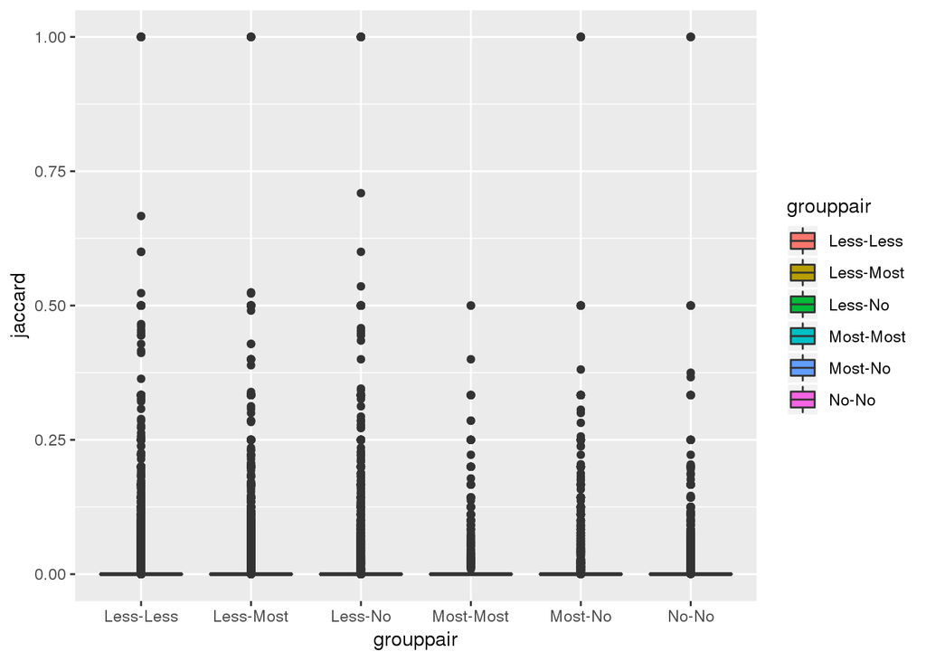

```r
# Create a boxplot showing the result of the jaccard coefficient for the pairs of drugs belonging to certain pairs of groups
p <- ggplot(mean_jac_df, aes(x=grouppair, y=jaccard, fill=grouppair)) +
  geom_boxplot()
#p <- ggplot(mean_jac_df, aes(factor(grouppair), jaccard)) +
#  geom_violin(aes(fill = grouppair))
p
```

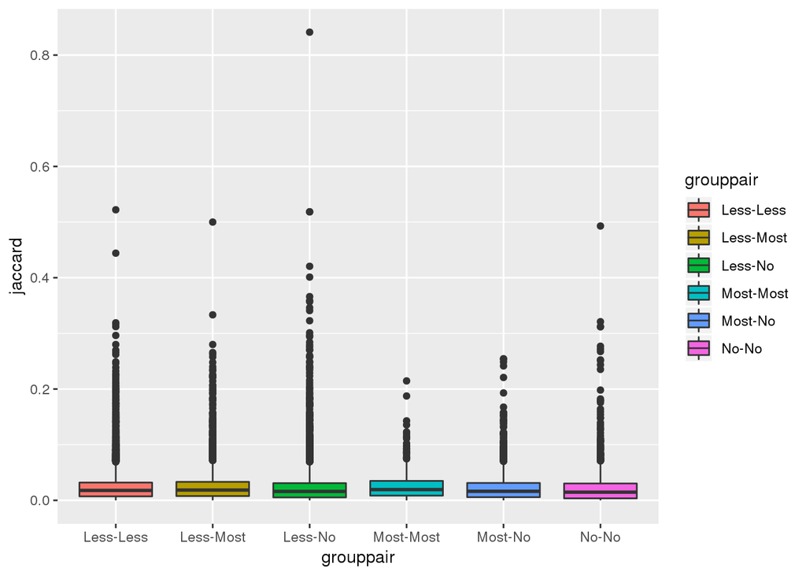

```r
p <- ggplot(diff_jac_df, aes(x=grouppair, y=jaccard, fill=grouppair)) +
  geom_boxplot()
p
```

### Considering only one specific condition

We will try to analyse the similarity in the expression of the genes comparing the pairs of drugs of the different DILIrank groups. But this time, we will choose specific conditions:

- **Cell ID**: HEPG2
- **Dose**: 10 µM
- **Time**: 6 h

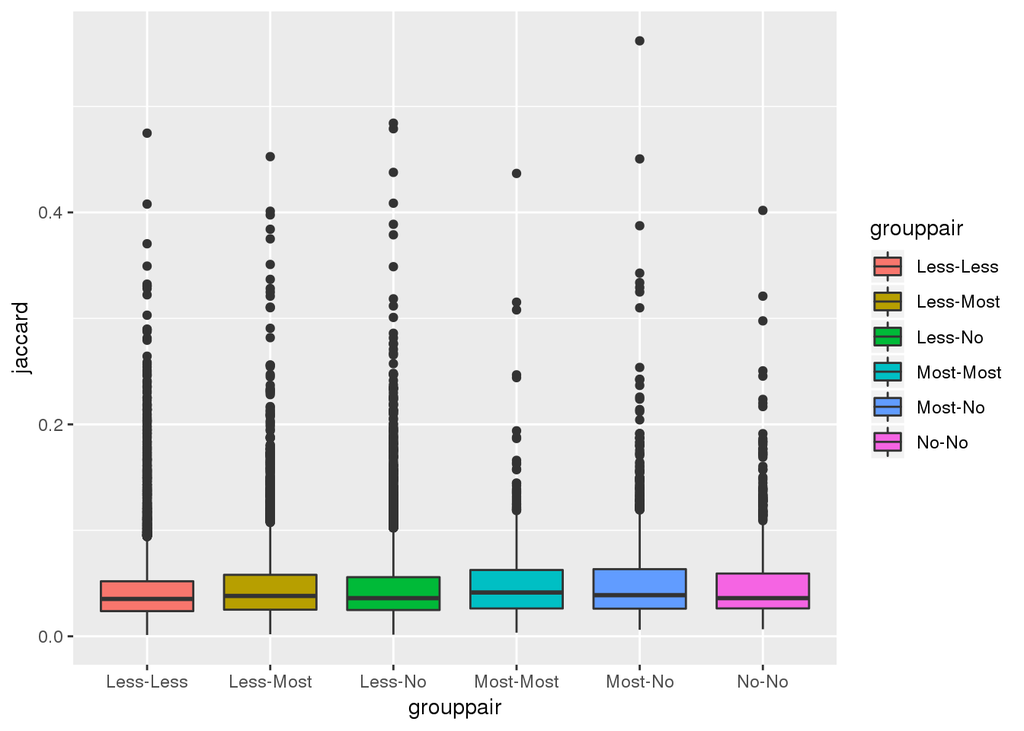

```r
# Conditions
cell_id <- "HEPG2"
dose <- "10 µM"
time <- "6 h"


# Create new dataframe to store 1 if abs(z-score)>1, 0 otherwise
spec_df <- data.frame(matrix(ncol = length(drank.sel$pert_iname), nrow = length(gct@rid)))
colnames(spec_df) <- drank.sel$pert_iname
rownames(spec_df) <- gct@rid

# Create new dataframe to store gene expression values for pca
pca_df <- data.frame(matrix(ncol = length(gct@rid), nrow = length(drank.sel$pert_iname)))
colnames(pca_df) <- gct@rid
rownames(pca_df) <- drank.sel$pert_iname

# Iterate over each drug
for (drug in drank.sel$pert_iname){
  # Get the subset of samples of the drug
  idx <- which(gct@cdesc$pert_iname==drug)
  x <- subset.gct(gct, cid=idx) # Subset by drug
  idx_c <- which(x@cdesc$cell_id==cell_id)
  x_c <- subset.gct(x, cid=idx_c) # Subset by cell ID
  idx_cd <- which(x_c@cdesc$pert_idose==dose)
  x_cd <- subset.gct(x_c, cid=idx_cd) # Subset by dose
  idx_cdt <- which(x_cd@cdesc$pert_itime==time)
  x_cdt <- subset.gct(x_cd, cid=idx_cdt) # Subset by time
  #print(paste(drug,length(x_cdt@cid)))
  if (length(x_cdt@cid) > 0){
    # Check for each gene if abs(z-score)>1. If so, return 1, otherwise, return 0
    diff <- apply(x_cdt@mat, 1, function(y){
        mn <- mean(y)
        ifelse(abs(mn)>1, 1, 0)
      })
    spec_df[,drug] <- diff
    pca_df[drug,] <- rowMeans(x_cdt@mat)
  } else {
    spec_df[drug] <- NULL
    pca_df[drug] <- NULL
  }
}


# Function to calculate the Jaccard Coefficient using as input values lists of 0s or 1s
Jaccard = function (x, y) {
    M.11 = sum(x == 1 & y == 1)
    M.10 = sum(x == 1 & y == 0)
    M.01 = sum(x == 0 & y == 1)
    if((M.11 + M.10 + M.01)==0){
      return (0)
    }else{
      return (M.11 / (M.11 + M.10 + M.01))
    }
}

# Create a dataframe to store the jaccard coefficient of each pair of drugs (using mean)
spec_jac_df <- data.frame(matrix(ncol = 6, nrow = 0))
colnames(spec_jac_df) <- c('drug1', 'group1', 'drug2', 'group2', 'grouppair', 'jaccard')

# For each pair of drugs, calculate the jaccard coefficient
drugs <- colnames(spec_df)
for (i in 1:length(drugs)){
  drug1 <- drugs[i]
  group1 <- drank.sel$DILIConcern[drank.sel$pert_iname==drug1]
  for (j in i:length(drugs)){
    drug2 <- drugs[j]
    group2 <- drank.sel$DILIConcern[drank.sel$pert_iname==drug2]
    grouppair <- paste(sort(c(group1, group2)),collapse="-")
    if (drug1 == drug2){
      next
    }

    jacindex <- Jaccard(spec_df[,drug1], spec_df[,drug2])
    if ( is.na(jacindex) | jacindex > 1 | jacindex < 0 ){
      print(paste(drug1, drug2, jacindex))
    }
    spec_jac_df[nrow(spec_jac_df)+1,] <- c(drug1, group1, drug2, group2, grouppair, jacindex)

  }
}

# Convert the jaccard to a numeric variable
spec_jac_df$grouppair <- as.character(spec_jac_df$grouppair)
spec_jac_df$jaccard <- as.numeric(spec_jac_df$jaccard)

# Plot the boxplot
p <- ggplot(spec_jac_df, aes(x=grouppair, y=jaccard, fill=grouppair)) +
  geom_boxplot()
p
```

Let’s calculate the PCA:

```r
# Example with mtcars
#mtcars.pca <- prcomp(mtcars[,c(1:7,10,11)], center = TRUE,scale. = TRUE)
#summary(mtcars.pca)
#ggbiplot(mtcars.pca)
#mtcars.pca <- prcomp(mtcars[,c(1:7,10,11)], center = TRUE,scale. = TRUE)
#mtcars.country <- c(rep("Japan", 3), rep("US",4), rep("Europe", 7),rep("US",3), "Europe", rep("Japan", 3), rep("US",4), rep("Europe", 3), "US", rep("Europe", 3))
#ggbiplot(mtcars.pca,ellipse=TRUE, groups=mtcars.country)

# Define the groups of the drugs
groups <- c()
drugs <- rownames(pca_df)
for (i in 1:length(drugs)){
  drug <- drugs[i]
  groups[i] <- drank.sel$DILIConcern[drank.sel$pert_iname==drug]
}
# Calculate the PCA
pca_df <- pca_df[rowSums(is.na(pca_df)) != ncol(pca_df), ]
cmapdata.pca <- prcomp(pca_df, center = TRUE,scale. = TRUE)
summary(cmapdata.pca)
```

```
## Importance of components:
##                          PC1      PC2      PC3      PC4      PC5      PC6
## Standard deviation     52.08 29.12098 18.65121 18.11794 17.60191 16.19052
## Proportion of Variance  0.22  0.06879  0.02822  0.02663  0.02513  0.02126
## Cumulative Proportion   0.22  0.28880  0.31702  0.34364  0.36878  0.39004
##                            PC7      PC8      PC9     PC10     PC11
## Standard deviation     14.9785 14.49949 14.31638 13.67684 13.16701
## Proportion of Variance  0.0182  0.01705  0.01663  0.01517  0.01406
## Cumulative Proportion   0.4082  0.42529  0.44192  0.45709  0.47115
##                            PC12     PC13     PC14     PC15     PC16
## Standard deviation     12.54420 12.02488 11.63253 11.30204 11.23376
## Proportion of Variance  0.01276  0.01173  0.01098  0.01036  0.01024
## Cumulative Proportion   0.48392  0.49565  0.50662  0.51699  0.52722
##                            PC17     PC18     PC19     PC20     PC21
## Standard deviation     10.89298 10.63019 10.53656 10.43748 10.13181
## Proportion of Variance  0.00963  0.00917  0.00901  0.00884  0.00833
## Cumulative Proportion   0.53685  0.54601  0.55502  0.56386  0.57218
##                           PC22    PC23    PC24    PC25    PC26    PC27
## Standard deviation     9.91478 9.77245 9.71996 9.51495 9.27036 9.17404
## Proportion of Variance 0.00797 0.00775 0.00766 0.00734 0.00697 0.00683
## Cumulative Proportion  0.58016 0.58790 0.59557 0.60291 0.60988 0.61671
##                           PC28    PC29   PC30    PC31    PC32    PC33
## Standard deviation     9.11150 8.94179 8.8809 8.77562 8.69570 8.59518
## Proportion of Variance 0.00673 0.00649 0.0064 0.00625 0.00613 0.00599
## Cumulative Proportion  0.62344 0.62993 0.6363 0.64257 0.64871 0.65470
##                           PC34    PC35    PC36    PC37    PC38    PC39
## Standard deviation     8.50330 8.32210 8.28525 8.25039 8.09110 8.04607
## Proportion of Variance 0.00587 0.00562 0.00557 0.00552 0.00531 0.00525
## Cumulative Proportion  0.66056 0.66618 0.67175 0.67727 0.68258 0.68783
##                           PC40    PC41    PC42    PC43    PC44   PC45
## Standard deviation     8.00273 7.90512 7.84597 7.74650 7.66033 7.6151
## Proportion of Variance 0.00519 0.00507 0.00499 0.00487 0.00476 0.0047
## Cumulative Proportion  0.69303 0.69810 0.70309 0.70796 0.71272 0.7174
##                           PC46    PC47    PC48    PC49    PC50    PC51
## Standard deviation     7.57804 7.50647 7.35294 7.29096 7.24491 7.13203
## Proportion of Variance 0.00466 0.00457 0.00439 0.00431 0.00426 0.00413
## Cumulative Proportion  0.72208 0.72665 0.73104 0.73535 0.73961 0.74373
##                           PC52    PC53    PC54    PC55    PC56    PC57
## Standard deviation     7.11844 7.06380 6.99589 6.98218 6.94700 6.82942
## Proportion of Variance 0.00411 0.00405 0.00397 0.00395 0.00391 0.00378
```

[output cut: 106 more lines]

```
## Standard deviation     2.11482 2.08207 2.06622 2.04358 2.03139 1.98217
## Proportion of Variance 0.00036 0.00035 0.00035 0.00034 0.00033 0.00032
## Cumulative Proportion  0.99479 0.99514 0.99548 0.99582 0.99616 0.99648
##                          PC220   PC221  PC222  PC223   PC224   PC225
## Standard deviation     1.97840 1.96070 1.9354 1.9152 1.90062 1.88805
## Proportion of Variance 0.00032 0.00031 0.0003 0.0003 0.00029 0.00029
## Cumulative Proportion  0.99679 0.99711 0.9974 0.9977 0.99800 0.99829
##                          PC226   PC227   PC228   PC229   PC230   PC231
## Standard deviation     1.83515 1.82178 1.79436 1.74229 1.70072 1.67870
## Proportion of Variance 0.00027 0.00027 0.00026 0.00025 0.00023 0.00023
## Cumulative Proportion  0.99856 0.99883 0.99909 0.99934 0.99957 0.99980
##                         PC232     PC233
## Standard deviation     1.5593 7.126e-15
## Proportion of Variance 0.0002 0.000e+00
## Cumulative Proportion  1.0000 1.000e+00
```

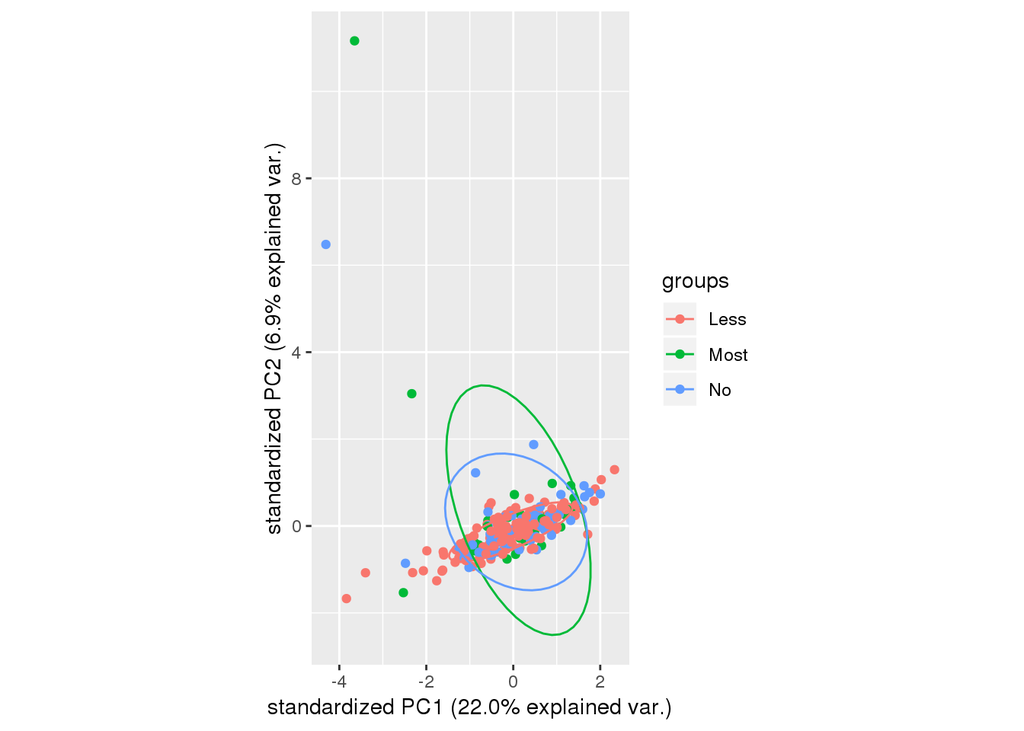

```r
# Plot the PCA
ggbiplot(cmapdata.pca,ellipse=TRUE,var.axes=FALSE, groups=groups)
```